# MovieLens Project Question Notebook

### `Project - MovieLens Data Analysis`

The GroupLens Research Project is a research group in the Department of Computer Science and Engineering at the University of Minnesota. The data is widely used for collaborative filtering and other filtering solutions. However, we will be using this data to act as a means to demonstrate our skill in using Python to “play” with data.

### `Objective:`

- To implement the techniques learnt as a part of the course.

### `Datasets Information:`

*rating.csv:* It contains information on ratings given by the users to a particular movie.

- user id: id assigned to every user
- movie id: id assigned to every movie
- rating: rating given by the user
- timestamp: Time recorded when the user gave a rating

*movie.csv:* File contains information related to the movies and their genre.

- movie id: id assigned to every movie
- movie title: Title of the movie
- release date: Date of release of the movie
- Action: Genre containing binary values (1 - for action 0 - not action)
- Adventure: Genre containing binary values (1 - for adventure 0 - not adventure)
- Animation: Genre containing binary values (1 - for animation 0 - not animation)
- Children’s: Genre containing binary values (1 - for children's 0 - not children's)
- Comedy: Genre containing binary values (1 - for comedy 0 - not comedy)
- Crime: Genre containing binary values (1 - for crime 0 - not crime)
- Documentary: Genre containing binary values (1 - for documentary 0 - not documentary)
- Drama: Genre containing binary values (1 - for drama 0 - not drama)
- Fantasy: Genre containing binary values (1 - for fantasy 0 - not fantasy)
- Film-Noir: Genre containing binary values (1 - for film-noir 0 - not film-noir)
- Horror: Genre containing binary values (1 - for horror 0 - not horror)
- Musical: Genre containing binary values (1 - for musical 0 - not musical)
- Mystery: Genre containing binary values (1 - for mystery 0 - not mystery)
- Romance: Genre containing binary values (1 - for romance 0 - not romance)
- Sci-Fi: Genre containing binary values (1 - for sci-fi 0 - not sci-fi)
- Thriller: Genre containing binary values (1 - for thriller 0 - not thriller)
- War: Genre containing binary values (1 - for war 0 - not war)
- Western: Genre containing binary values (1 - for western - not western)

*user.csv:* It contains information of the users who have rated the movies.

- user id: id assigned to every user
- age: Age of the user
- gender: Gender of the user
- occupation: Occupation of the user
- zip code: Zip code of the use

**`Please provide your insights wherever necessary.`**

### `Learning Outcomes:`

- Exploratory Data Analysis
- Visualization using Python
- Pandas – groupby, merging

### `Domain`

- Internet and Entertainment

**Note that the project will need you to apply the concepts of groupby and merging extensively.**

### 1. Import the necessary packages - 2.5 marks

```python
#your code here
import pandas as pd
import numpy as np
import seaborn as sns
import matplotlib.pyplot as plt
import scipy.stats as stats
import warnings
import datetime
warnings.filterwarnings('ignore')
%matplotlib inline
```

### 2. Read the 3 datasets into dataframes - 2.5 marks

```python
#your code here
userdata       = pd.read_csv("user.csv")
itemdata       = pd.read_csv("item.csv")
userratingdata = pd.read_csv("userrating.csv")
```

### 3. Apply info, shape, describe, and find the number of missing values in the data. Present at least 3 observations from these operations - 2.5 marks

- Note that you will need to do it for all the three datasets seperately

```python
#userdata
userdata.info()
userdata.describe().transpose()
```

```
<class 'pandas.core.frame.DataFrame'>
RangeIndex: 943 entries, 0 to 942
Data columns (total 5 columns):
 #   Column      Non-Null Count  Dtype
---  ------      --------------  -----
 0   user id     943 non-null    int64
 1   age         943 non-null    int64
 2   gender      943 non-null    object
 3   occupation  943 non-null    object
 4   zip code    943 non-null    object
dtypes: int64(2), object(3)
memory usage: 37.0+ KB
```

|  | count | mean | std | min | 25% | 50% | 75% | max |
| --- | --- | --- | --- | --- | --- | --- | --- | --- |
| user id | 943.0 | 472.000000 | 272.364951 | 1.0 | 236.5 | 472.0 | 707.5 | 943.0 |
| age | 943.0 | 34.051962 | 12.192740 | 7.0 | 25.0 | 31.0 | 43.0 | 73.0 |

```python
#moviedata
itemdata.info()
#itemdata.head(10)
itemdata.describe().transpose()
```

```
<class 'pandas.core.frame.DataFrame'>
RangeIndex: 1681 entries, 0 to 1680
Data columns (total 22 columns):
 #   Column        Non-Null Count  Dtype
---  ------        --------------  -----
 0   movie id      1681 non-null   int64
 1   movie title   1681 non-null   object
 2   release date  1681 non-null   object
 3   unknown       1681 non-null   int64
 4   Action        1681 non-null   int64
 5   Adventure     1681 non-null   int64
 6   Animation     1681 non-null   int64
 7   Childrens     1681 non-null   int64
 8   Comedy        1681 non-null   int64
 9   Crime         1681 non-null   int64
 10  Documentary   1681 non-null   int64
 11  Drama         1681 non-null   int64
 12  Fantasy       1681 non-null   int64
 13  Film-Noir     1681 non-null   int64
 14  Horror        1681 non-null   int64
 15  Musical       1681 non-null   int64
 16  Mystery       1681 non-null   int64
 17  Romance       1681 non-null   int64
 18  Sci-Fi        1681 non-null   int64
 19  Thriller      1681 non-null   int64
 20  War           1681 non-null   int64
 21  Western       1681 non-null   int64
dtypes: int64(20), object(2)
memory usage: 289.0+ KB
```

|  | count | mean | std | min | 25% | 50% | 75% | max |
| --- | --- | --- | --- | --- | --- | --- | --- | --- |
| movie id | 1681.0 | 841.841761 | 485.638077 | 1.0 | 422.0 | 842.0 | 1262.0 | 1682.0 |
| unknown | 1681.0 | 0.000595 | 0.024390 | 0.0 | 0.0 | 0.0 | 0.0 | 1.0 |
| Action | 1681.0 | 0.149316 | 0.356506 | 0.0 | 0.0 | 0.0 | 0.0 | 1.0 |
| Adventure | 1681.0 | 0.080309 | 0.271852 | 0.0 | 0.0 | 0.0 | 0.0 | 1.0 |
| Animation | 1681.0 | 0.024985 | 0.156126 | 0.0 | 0.0 | 0.0 | 0.0 | 1.0 |
| Childrens | 1681.0 | 0.072576 | 0.259516 | 0.0 | 0.0 | 0.0 | 0.0 | 1.0 |
| Comedy | 1681.0 | 0.300416 | 0.458576 | 0.0 | 0.0 | 0.0 | 1.0 | 1.0 |
| Crime | 1681.0 | 0.064842 | 0.246321 | 0.0 | 0.0 | 0.0 | 0.0 | 1.0 |
| Documentary | 1681.0 | 0.029744 | 0.169931 | 0.0 | 0.0 | 0.0 | 0.0 | 1.0 |
| Drama | 1681.0 | 0.431291 | 0.495404 | 0.0 | 0.0 | 0.0 | 1.0 | 1.0 |
| Fantasy | 1681.0 | 0.013087 | 0.113683 | 0.0 | 0.0 | 0.0 | 0.0 | 1.0 |
| Film-Noir | 1681.0 | 0.014277 | 0.118667 | 0.0 | 0.0 | 0.0 | 0.0 | 1.0 |
| Horror | 1681.0 | 0.054729 | 0.227519 | 0.0 | 0.0 | 0.0 | 0.0 | 1.0 |
| Musical | 1681.0 | 0.033314 | 0.179507 | 0.0 | 0.0 | 0.0 | 0.0 | 1.0 |
| Mystery | 1681.0 | 0.036288 | 0.187061 | 0.0 | 0.0 | 0.0 | 0.0 | 1.0 |
| Romance | 1681.0 | 0.146936 | 0.354148 | 0.0 | 0.0 | 0.0 | 0.0 | 1.0 |
| Sci-Fi | 1681.0 | 0.060083 | 0.237712 | 0.0 | 0.0 | 0.0 | 0.0 | 1.0 |
| Thriller | 1681.0 | 0.149316 | 0.356506 | 0.0 | 0.0 | 0.0 | 0.0 | 1.0 |
| War | 1681.0 | 0.042237 | 0.201189 | 0.0 | 0.0 | 0.0 | 0.0 | 1.0 |
| Western | 1681.0 | 0.016062 | 0.125751 | 0.0 | 0.0 | 0.0 | 0.0 | 1.0 |

```python
#userdata
userratingdata.info()
userratingdata.describe().transpose()
```

```
<class 'pandas.core.frame.DataFrame'>
RangeIndex: 100000 entries, 0 to 99999
Data columns (total 4 columns):
 #   Column     Non-Null Count   Dtype
---  ------     --------------   -----
 0   user id    100000 non-null  int64
 1   movie id   100000 non-null  int64
 2   rating     100000 non-null  int64
 3   timestamp  100000 non-null  int64
dtypes: int64(4)
memory usage: 3.1 MB
```

|  | count | mean | std | min | 25% | 50% | 75% | max |
| --- | --- | --- | --- | --- | --- | --- | --- | --- |
| user id | 100000.0 | 4.624848e+02 | 2.666144e+02 | 1.0 | 254.0 | 447.0 | 682.0 | 943.0 |
| movie id | 100000.0 | 4.255301e+02 | 3.307984e+02 | 1.0 | 175.0 | 322.0 | 631.0 | 1682.0 |
| rating | 100000.0 | 3.529860e+00 | 1.125674e+00 | 1.0 | 3.0 | 4.0 | 4.0 | 5.0 |
| timestamp | 100000.0 | 8.835289e+08 | 5.343856e+06 | 874724710.0 | 879448709.5 | 882826944.0 | 888259984.0 | 893286638.0 |

**Observations:** userdata observations: Dataset has 5 columns. it has 943 records with actual values,min age is 7 years and max age is 73. itemdata observations: Dataset has 22 columns. It has 1681 records with actual values. userratingsdata observations: Dataset has 4 columns. It has 100000 records with actual values, user can give a minimum rating as 1 and maximum as 5. There are no missing values in the given three data asets userdata,moviedata and ratings data. Movies genre catogerical data is converted to nuemerical data by using 0/1.

### 4. Find the number of movies per genre using the item data - 2.5 marks

```python
#your code here
itemdata[['unknown','Action', 'Adventure', 'Animation','Childrens','Comedy','Crime','Documentary','Drama','Fantasy','Film-Noir','Horror','Musical','Mystery','Romance','Sci-Fi','Thriller','War','Western']].eq(1).sum()
```

```
unknown          1
Action         251
Adventure      135
Animation       42
Childrens      122
Comedy         505
Crime          109
Documentary     50
Drama          725
Fantasy         22
Film-Noir       24
Horror          92
Musical         56
Mystery         61
Romance        247
Sci-Fi         101
Thriller       251
War             71
Western         27
dtype: int64
```

**Insights:** Once movie with unknow genre and Drama has more number of movies.

### 5. Drop the movie where the genre is unknown - 2.5 marks

```python
#your code here
itemdata = itemdata.drop(itemdata[(itemdata.unknown == 1)].index)
itemdata[['unknown','Action', 'Adventure', 'Animation','Childrens','Comedy','Crime','Documentary','Drama','Fantasy','Film-Noir','Horror','Musical','Mystery','Romance','Sci-Fi','Thriller','War','Western']].eq(1).sum()
```

```
unknown          0
Action         251
Adventure      135
Animation       42
Childrens      122
Comedy         505
Crime          109
Documentary     50
Drama          725
Fantasy         22
Film-Noir       24
Horror          92
Musical         56
Mystery         61
Romance        247
Sci-Fi         101
Thriller       251
War             71
Western         27
dtype: int64
```

**Insights:** One Unknow movie is dropped from the itemdata

### 6. Find the movies that have more than one genre - 5 marks

hint: use sum on the axis = 1

Display movie name, number of genres for the movie in dataframe

and also print(total number of movies which have more than one genres)

```python
#your code here
itemdata['movie title'].nunique()
itemdata.groupby(['movie title'])['Action', 'Adventure', 'Animation','Childrens','Comedy','Crime','Documentary','Drama','Fantasy','Film-Noir','Horror','Musical','Mystery','Romance','Sci-Fi','Thriller','War','Western'].sum().sum(axis=1)
itemdata1 =itemdata.groupby(['movie title'])['Action', 'Adventure', 'Animation','Childrens','Comedy','Crime','Documentary','Drama','Fantasy','Film-Noir','Horror','Musical','Mystery','Romance','Sci-Fi','Thriller','War','Western'].sum().sum(axis=1).reset_index()
total_rows =itemdata1[itemdata1[0] >1].count()
print( total_rows[0])
```

```
848
```

**Insights:** There are 809 movies that has only one genre, One movie that has no genre and 848 movies that has more than one genre.

### 7. Univariate plots of columns: 'rating', 'Age', 'release year', 'Gender' and 'Occupation' - 10 marks

*HINT: Use distplot for age and countplot for release year, ratings,*

*HINT: Please refer to the below snippet to understand how to get to release year from release date. You can use str.split() as depicted below or you could convert it to pandas datetime format and extract year (.dt.year)*

```python
a = 'My*cat*is*brown'
print(a.split('*')[3])

#similarly, the release year needs to be taken out from release date

#also you can simply slice existing string to get the desired data, if we want to take out the colour of the cat

print(a[10:])
print(a[-5:])
```

```
brown
brown
brown
```

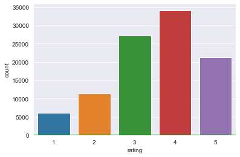

[figure not shown]

```python
#your code here
#Univariate displot for Age
sns.distplot(userdata['age'],color='g',axlabel='Age', kde=True);
#Univariate countplot for ratings
sns.countplot(x='rating', data=userratingdata);
#Univariate countplot for release year
itemdata['release year'] = pd.DatetimeIndex(itemdata['release date']).year
f = plt.figure(figsize=(20,5))
sns.countplot(x='release year', data=itemdata,palette="Set3",orient='H',dodge='bool');
#Univariate countplot for Gender
sns.countplot(x='gender', data=userdata);
#Univariate countplot for Occupation
sns.countplot(x='occupation', data=userdata);
```

### 8. Visualize how popularity of genres has changed over the years - 10 marks

Note that you need to use the **percent of number of releases in a year** as a parameter of popularity of a genre

Hint 1: You need to reach to a data frame where the release year is the index and the genre is the column names (one cell shows the number of release in a year in one genre) or vice versa. (Drop unnecessary column if there are any)

Hint 2: Find the total number of movies release in a year(use item dataset to get count of movies released in a particular year, store that value in a new column as 'total'). Now divide the value of each genre in that year by total to get percentage number of release in a particular year. `(df.div(df['total'], axis= 0) * 100)`

Once that is achieved, you can either use univariate plots or can use the heatmap to visualise all the changes over the years in one go.

Hint 3: Use groupby on the relevant column and use sum() on the same to find out the number of releases in a year/genre.

```
<class 'pandas.core.frame.DataFrame'>
RangeIndex: 71 entries, 0 to 70
Data columns (total 19 columns):
 #   Column        Non-Null Count  Dtype
---  ------        --------------  -----
 0   release year  71 non-null     int64
 1   Action        71 non-null     int64
 2   Adventure     71 non-null     int64
 3   Animation     71 non-null     int64
 4   Childrens     71 non-null     int64
 5   Comedy        71 non-null     int64
 6   Crime         71 non-null     int64
 7   Documentary   71 non-null     int64
 8   Drama         71 non-null     int64
 9   Fantasy       71 non-null     int64
 10  Film-Noir     71 non-null     int64
 11  Horror        71 non-null     int64
 12  Musical       71 non-null     int64
 13  Mystery       71 non-null     int64
 14  Romance       71 non-null     int64
 15  Sci-Fi        71 non-null     int64
 16  Thriller      71 non-null     int64
 17  War           71 non-null     int64
 18  Western       71 non-null     int64
dtypes: int64(19)
memory usage: 10.7 KB
```

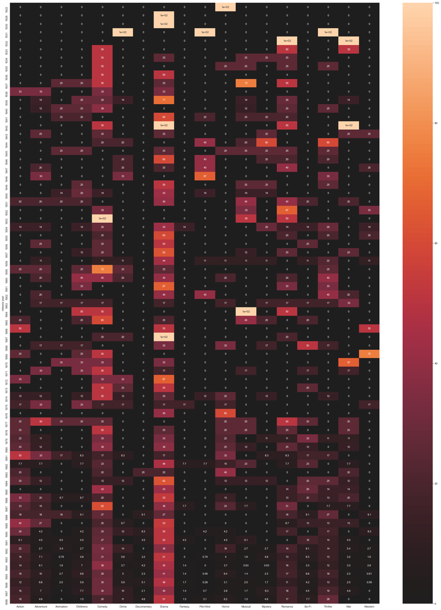

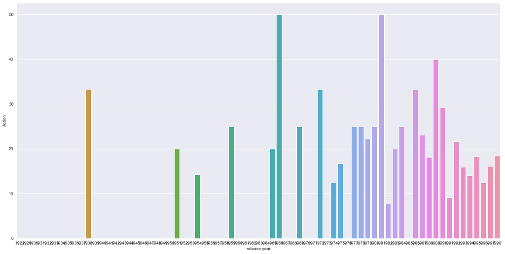

```python
#your code here
itemdata1 =itemdata.groupby(['release year'])['Action', 'Adventure', 'Animation','Childrens','Comedy','Crime','Documentary','Drama','Fantasy','Film-Noir','Horror','Musical','Mystery','Romance','Sci-Fi','Thriller','War','Western'].sum().reset_index('release year')
itemdata1.info()
#itemdata1.head(30)
itemdata1.set_index(['release year'],inplace =True)
itemdata2 = itemdata.groupby(['release year'])['movie id'].count().reset_index('release year')
itemdata2.set_index(['release year'],inplace =True)
itemdata2.rename(columns={"movie id": "total"},inplace=True)
itemdata3 =itemdata1.merge(itemdata2, left_on='release year', right_on='release year')
itemdata4 = itemdata3[['Action', 'Adventure', 'Animation','Childrens','Comedy','Crime','Documentary','Drama','Fantasy','Film-Noir','Horror','Musical','Mystery','Romance','Sci-Fi','Thriller','War','Western']].div(itemdata3.total, axis=0)*100
f = plt.figure(figsize=(30,40))
sns.heatmap(itemdata4, center=0, annot=True);
itemdata4.reset_index(inplace=True)
plt.figure(figsize=(20,10))
sns.barplot(data=itemdata4,x='release year',y='Action');
```

### 9. Find the top 25 movies in terms of average ratings for movies that have been rated more than 100 times - 10 marks

Hints :

1. Find the count of ratings and average ratings for every movie.
2. Slice the movies which have ratings more than 100.
3. Sort values according to average rating such that movie which highest rating is on top.
4. Select top 25 movies.
5. You will have to use the .merge() function to get the movie titles.

Note: This question will need you to research about groupby and apply your findings. You can find more on groupby on https://realpython.com/pandas-groupby/.

```python
#your code here
userratingdata1 =itemdata.merge(userratingdata, left_on='movie id', right_on='movie id')
#userratingdata1.info()
#userratingdata1.head(5)
userratingdata2 = userratingdata1.groupby('movie title').agg({'rating': [np.size, np.mean]})
userratingdata2.reset_index()
#userratingdata2.info()
#userratingdata3 = userratingdata2['rating','size'] > 100
userratingdata3  = userratingdata2.loc[userratingdata2['rating','size'] > 100]
userratingdata3.sort_values([('rating', 'mean')],ascending=False).head(25)
```

| movie title | rating size | rating mean |
| --- | --- | --- |
| Close Shave, A | 112 | 4.491071 |
| Schindler's List | 298 | 4.466443 |
| Wrong Trousers, The | 118 | 4.466102 |
| Casablanca | 243 | 4.456790 |
| Shawshank Redemption, The | 283 | 4.445230 |
| Rear Window | 209 | 4.387560 |
| Usual Suspects, The | 267 | 4.385768 |
| Star Wars | 583 | 4.358491 |
| 12 Angry Men | 125 | 4.344000 |
| Citizen Kane | 198 | 4.292929 |
| To Kill a Mockingbird | 219 | 4.292237 |
| One Flew Over the Cuckoo's Nest | 264 | 4.291667 |
| Silence of the Lambs, The | 390 | 4.289744 |
| North by Northwest | 179 | 4.284916 |
| Godfather, The | 413 | 4.283293 |
| Secrets & Lies | 162 | 4.265432 |
| Good Will Hunting | 198 | 4.262626 |
| Manchurian Candidate, The | 131 | 4.259542 |
| Dr. Strangelove or: How I Learned to Stop Worrying and Love the Bomb | 194 | 4.252577 |
| Raiders of the Lost Ark | 420 | 4.252381 |
| Vertigo | 179 | 4.251397 |
| Titanic | 350 | 4.245714 |
| Lawrence of Arabia | 173 | 4.231214 |
| Maltese Falcon, The | 138 | 4.210145 |
| Empire Strikes Back, The | 367 | 4.204360 |

### 10. Check for the validity of the below statements with respect to the data provided - 10 marks

- Men watch more drama than women
- Women watch more Sci-Fi than men
- Men watch more Romance than women

**compare the percentages**

**Please pay attention to what should be the denominator while calculating percentages**

1. Merge all the datasets
2. There is no need to conduct statistical tests around this. Just **compare the percentages** and comment on the validity of the above statements.
3. you might want ot use the .sum(), .div() function here.
4. Use number of ratings to validate the numbers. For example, if out of 4000 ratings received by women, 3000 are for drama, we will assume that 75% of the women watch drama.

```python
#your code here
ratingdata1 =userdata.merge(userratingdata, left_on='user id', right_on='user id')
ratingdata  = ratingdata1.merge(itemdata,left_on='movie id', right_on='movie id')
#ratingdata.info()
ftotalratings = len(ratingdata[ratingdata['gender']=='F'])
print("ftotalratings : ")
print(ftotalratings)
mtotalratings = len(ratingdata[ratingdata['gender']=='M'])
print('mtotalratings :')
print(mtotalratings)
fdramaratings = len(ratingdata[((ratingdata['gender']=='F') & (ratingdata['Drama']==1))])
#print('fdramaratings :')
#print(fdramaratings)
fdramarapctg  = (fdramaratings/ftotalratings)*100
print('fdramapctg :')
print(fdramarapctg)
mdramaratings = len(ratingdata[((ratingdata['gender']=='M') & (ratingdata['Drama']==1))])
#print('mdramaratings :')
#print(mdramaratings)
mdramarapctg  = (mdramaratings/mtotalratings)*100
print('mdramarapctg :')
print(mdramarapctg)

fscifiratings = len(ratingdata[((ratingdata['gender']=='F') & (ratingdata['Sci-Fi']==1))])
#print('fscifiratings :')
#print(fscifiratings)
fscifirapctg  = (fscifiratings/ftotalratings)*100
print('fscifipctg :')
print(fscifirapctg)
mscifiratings = len(ratingdata[((ratingdata['gender']=='M') & (ratingdata['Sci-Fi']==1))])
#print('mscifiratings :')
#print(mscifiratings)
mscifirapctg  = (mscifiratings/mtotalratings)*100
print('mscifirapctg :')
print(mscifirapctg)

fromanceratings = len(ratingdata[((ratingdata['gender']=='F') & (ratingdata['Romance']==1))])
#print('fromanceratings :')
#print(fromanceratings)
fromancerapctg  = (fromanceratings/ftotalratings)*100
print('fromancepctg :')
print(fromancerapctg)
mromanceratings = len(ratingdata[((ratingdata['gender']=='M') & (ratingdata['Romance']==1))])
#print('mromanceratings :')
#print(mromanceratings)
mromancerapctg  = (mromanceratings/mtotalratings)*100
print('mromancerapctg :')
print(mromancerapctg)
```

```
ftotalratings :
25738
mtotalratings :
74252
fdramapctg :
42.76944595539669
mdramarapctg :
38.90400258578893
fscifipctg :
10.214468878700753
mscifirapctg :
13.603673975111782
fromancepctg :
22.760121221540135
mromancerapctg :
18.320045251306365
```

**Conclusion:** By Looking at the calculations, Women watch more Drama than Men. Men watch more Sci-fi than Women. Women watch more romance than Men.